# AZ Case Study: openFDA Analysis

Lilia Bouzit

5/4/2020

## Are different adverse events associated with different auto-immune disorders?

I am interested in looking at the different adverse events associated with different diseases, specifically auto-immune disorders that are commonly treated with pharmaceuticals. In this exploration, I will use the openFDA web API to pull reports with the following diseases listed as a drug indication: Rheumatoid arthritis Psoriasis Crohn’s disease Lupus Multiple Sclerosis Ulcerative Colitis Ankylosing spondylitis

Then, I will examine the adverse events that appear on the same reports. After testing out several search terms for the seven diseases by querying the web API, I decided on the query search below. Due to limitations in how many records one can pull from the web API at a time, I decided to limit the time frame of interest to 6-month window in 2019. Then, I looked up the total report count for my search term from the ‘total’ field in the ‘meta’ object of the JSON record.

```r
get.meta<-fromJSON("https://api.fda.gov/drug/event.json?search=(receivedate:[20190101+TO+20190630])+AND+patient.patientonsetage:[18+TO+110]+AND+_exists_:patient.reaction.reactionmeddrapt+(patient.drug.drugindication:\"rheumatoid+arthritis\"+\"psoriasis\"+crohn+lupus+sclerosis+\"colitis+ulcerative\"+\"ankylosing+spondylitis\")&limit=1")
```

There are 365448 reports found from this query. However, there are limitations in place on the number of reports that can be downloaded from one query, the max is 100 reports. For a more thorough project (and with the appropriate computational resources), it would be ideal to use the downloads provided by openFDA and create a relational database. For the purposes of this case study, I will make use of the ‘skip’ parameter to pull more paginated reports.

### Loading in the data

First, I initialize a dataframe that converted the JSON data to nested dataframe objects. Then, I run a script to add more pages of 100 reports for a total of 25,000 reports.

```r
dt.init<-fromJSON("https://api.fda.gov/drug/event.json?search=_exists_:patient.drug.drugindication+AND+_exists_:patient.reaction.reactionmeddrapt+AND+receivedate:[20190101+TO+20190630]+AND+patient.patientonsetage:[18+TO+110]+AND+(patient.drug.drugindication:\"rheumatoid+arthritis\"+\"psoriasis\"+crohn+lupus+sclerosis+\"colitis+ulcerative\"+\"ankylosing+spondylitis\")&limit=100")

dt.init2<-fromJSON("https://api.fda.gov/drug/event.json?search=_exists_:patient.drug.drugindication+AND+_exists_:patient.reaction.reactionmeddrapt+AND+receivedate:[20190101+TO+20190630]+AND+patient.patientonsetage:[18+TO+110]+AND+(patient.drug.drugindication:\"rheumatoid+arthritis\"+\"psoriasis\"+crohn+lupus+sclerosis+\"colitis+ulcerative\"+\"ankylosing+spondylitis\")&limit=100&skip=100")


dt <- rbind_pages(list(dt.init$results$patient, dt.init2$results$patient))

for(i in seq(3:250)){

  temp<-fromJSON(sprintf("https://api.fda.gov/drug/event.json?search=_exists_:patient.drug.drugindication+AND+_exists_:patient.reaction.reactionmeddrapt+AND+receivedate:[20190101+TO+20190630]+AND+patient.patientonsetage:[18+TO+105]+AND+(patient.drug.drugindication:\"rheumatoid+arthritis\"+\"psoriasis\"+crohn+lupus+sclerosis+\"colitis+ulcerative\"+\"ankylosing+spondylitis\")&limit=100&skip=%s", as.character(i*100)) )

  dt<-rbind_pages(list(dt, temp$results$patient))

}
```

### Converting the JSON objects to a dataframe

To explore my question, I am interested in the ‘drugindication’ field to represent the disease and the ‘reactionmeddrapt’ field to represent the adverse event. I select these two fields, keep track of their relationship with an event ID counter, and create a data frame in long format. I also remove any occurence of the diseases in the adverse event field in order to focus on insights of other adverse events.

```r
ind_name<-c()
reac_name<-c()
eventid<-c(seq(1:25000))
id1<-c()
id2<-c()
for(i in seq(1:25000)){
  l1<-list(unique(dt$drug[[i]]$drugindication))
  ind_name[i]<-l1
  id1[i]<-list(c(rep(i, length(unlist(l1)))))

  l2<-list(dt$reaction[[i]]$reactionmeddrapt)
  reac_name[i]<-l2
  id2[i]<-list(c(rep(i, length(unlist(l2)))))

}

diseases<-c("RHEUMATOID ARTHRITIS", "PSORIASIS", "COLITIS ULCERATIVE", "CROHN^S DISEASE", "SYSTEMIC LUPUS ERYTHEMATOSUS", "MULTIPLE SCLEROSIS", "ANKYLOSING SPONDYLITIS")

reaction<-as.data.frame(cbind(unlist(id2), unlist(reac_name)))
names(reaction)<-c("eventid", "reac_name")
reaction$reac_name<-toupper(reaction$reac_name)
reaction <- reaction %>% filter(!(reac_name %in% diseases))

indication<-as.data.frame(cbind(unlist(id1), unlist(ind_name)))
names(indication)<-c("eventid", "ind_name")


reac.hits<- reaction %>% group_by(reac_name) %>% summarise(n.reac=n())  %>% arrange(desc(n.reac))
ind.hits<- indication %>% group_by(ind_name) %>% summarise(n.ind=n())  %>% arrange(desc(n.ind))
```

In this sample of reports, there are 4792 unique adverse events recorded, and 1201 unique drug indications reported.

Finally, I look at the data by tabulating the 15 most common adverse events or reactions and 15 most common drug indications. As expected, all the auto-immune diseases will appear in the top 15, and other represented indications could be comorbidities of the patient population captured by these case reports.

```r
print(reac.hits[1:15,])
```

```
## # A tibble: 15 x 2
##    reac_name                   n.reac
##    <chr>                        <int>
##  1 DRUG INEFFECTIVE              2538
##  2 FATIGUE                       1496
##  3 HEADACHE                      1305
##  4 NAUSEA                        1243
##  5 PAIN                          1243
##  6 DIARRHOEA                     1218
##  7 ARTHRALGIA                    1149
##  8 INJECTION SITE PAIN           1097
##  9 FALL                          1026
## 10 MALAISE                        978
## 11 DEVICE ISSUE                   959
## 12 PRODUCT DOSE OMISSION          952
## 13 NASOPHARYNGITIS                920
## 14 INCORRECT DOSE ADMINISTERED    915
## 15 OFF LABEL USE                  851
```

```r
print(ind.hits[1:15,])
```

```
## # A tibble: 15 x 2
##    ind_name                               n.ind
##    <fct>                                  <int>
##  1 RHEUMATOID ARTHRITIS                    8458
##  2 <NA>                                    8077
##  3 MULTIPLE SCLEROSIS                      5798
##  4 PRODUCT USED FOR UNKNOWN INDICATION     5248
##  5 PSORIASIS                               4360
##  6 CROHN^S DISEASE                         2606
##  7 COLITIS ULCERATIVE                      1254
##  8 ANKYLOSING SPONDYLITIS                   928
##  9 PSORIATIC ARTHROPATHY                    840
## 10 HYPERTENSION                             697
## 11 RELAPSING-REMITTING MULTIPLE SCLEROSIS   565
## 12 GAIT DISTURBANCE                         507
## 13 PAIN                                     448
## 14 SYSTEMIC LUPUS ERYTHEMATOSUS             389
## 15 DEPRESSION                               318
```

### Initial summary statistics

Now, I prepare the data for further examination of the associations between adverse events and diseases. Using the event ID key, I find the counts of each adverse event for each disease. There is variation in the number of reports for each disease and therefore the counts are converted to proportions, in which the denominators are the number of reports for each disease.

Next, I compute and print summary statistics to examine the distribution of event frequencies.

```r
dt.merge<-merge(reaction, indication, by="eventid")
dt.merge<-na.omit(dt.merge)
dt.agg <- as.data.frame(dt.merge %>% group_by(ind_name, reac_name) %>% count(reac_name))

diseases.count.temp<-c()
for(i in seq(1:length(diseases))){
  diseases.count.temp[i]<-table(indication$ind_name)[paste(diseases[i])]
}
diseases.count<-cbind(diseases, diseases.count.temp)

dt.prop<-merge(dt.agg, diseases.count, by.x="ind_name", by.y="diseases")
dt.prop$n.prop<-dt.prop$n/as.integer(as.character(dt.prop$diseases.count))

dt.prop.filt <- dt.prop %>% filter((ind_name %in% diseases))
dt.prop.filt<-droplevels(dt.prop.filt)

summary.stats<-dt.prop.filt  %>% group_by(ind_name) %>% summarize(mean = mean(n.prop), sd = sd(n.prop), min=min(n.prop), median=median(n.prop), max=max(n.prop))
summary.stats
```

```
## # A tibble: 7 x 6
##   ind_name                        mean      sd      min   median    max
##   <fct>                          <dbl>   <dbl>    <dbl>    <dbl>  <dbl>
## 1 ANKYLOSING SPONDYLITIS       0.00394 0.00812 0.00108  0.00108  0.0851
## 2 COLITIS ULCERATIVE           0.00350 0.00867 0.000797 0.000797 0.104
## 3 CROHN^S DISEASE              0.00233 0.00702 0.000384 0.000767 0.105
## 4 MULTIPLE SCLEROSIS           0.00165 0.00602 0.000172 0.000345 0.0997
## 5 PSORIASIS                    0.00150 0.00488 0.000229 0.000459 0.0748
## 6 RHEUMATOID ARTHRITIS         0.00154 0.00595 0.000118 0.000236 0.179
## 7 SYSTEMIC LUPUS ERYTHEMATOSUS 0.00640 0.00922 0.00257  0.00257  0.0874
```

```r
quantile(dt.prop.filt$n.prop, c(.90, .95, .99))
```

```
##         90%         95%         99%
## 0.004784689 0.009569378 0.032920015
```

There are over 11,000 pairs of adverse events and diseases reported. The summary statistics show that the distribution of event frequencies are highly skewed, and there are many adverse events that are recorded with very low frequency. 99% of events each make up less than 3% of the total events.

### Visualize the most frequent adverse events

Since there are thousands of pairs, I implement a very high threshold of 3% in order to visualize the 57 most common events in a heatmap for the seven diseases of interest. This will restrict the visualization to approximately the top 1% of hits.

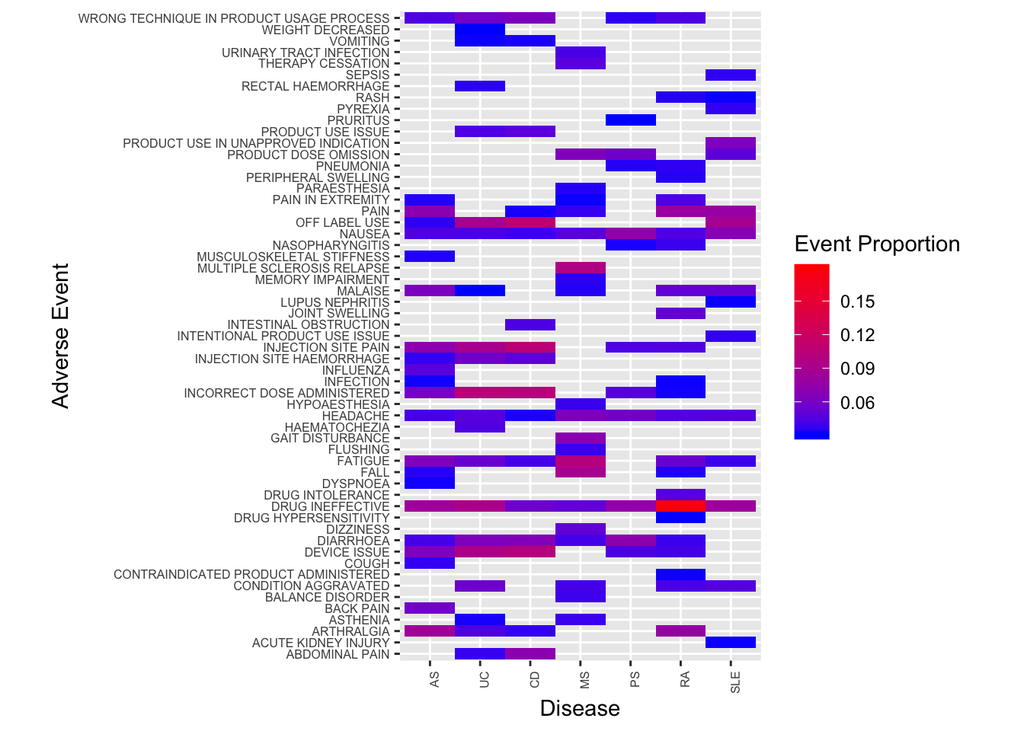

```r
dt.top.reac<-dt.prop[which(dt.prop$n.prop > 0.03),]
dt.top.reac<-dt.top.reac[order(dt.top.reac$ind_name, dt.top.reac$reac_name),]

top.heatmap <- ggplot(data = dt.top.reac, mapping = aes(x = ind_name, y = reac_name, fill = n.prop)) +
  geom_tile() +
   labs(
    x = "Disease",
    y = "Adverse Event",
    fill = "Event Proportion")+
  scale_fill_gradient(low = "blue", high = "red")+
  theme(axis.text.x  = element_text(angle=90, hjust=1, size=6), axis.text.y  = element_text(size=6), aspect.ratio=1.8)+
  scale_x_discrete(labels=c("ANKYLOSING SPONDYLITIS"="AS","COLITIS ULCERATIVE"="UC", "CROHN^S DISEASE"="CD", "MULTIPLE SCLEROSIS"="MS", "PSORIASIS"="PS", "RHEUMATOID ARTHRITIS"="RA", "SYSTEMIC LUPUS ERYTHEMATOSUS"="SLE"))
top.heatmap
```

### Measure correlation

Next, we can check if the diseases are correlated with respect to the adverse events. This will first require that the data is transformed from long to wide format.

```r
dt.wide <- dcast(dt.prop.filt, reac_name~ind_name, value.var="n.prop")
dt.wide[is.na(dt.wide)] <- 0

cor.mat = cor(dt.wide[-1])
cor.mat
```

```
##                              ANKYLOSING SPONDYLITIS COLITIS ULCERATIVE
## ANKYLOSING SPONDYLITIS                    1.0000000          0.7997522
## COLITIS ULCERATIVE                        0.7997522          1.0000000
## CROHN^S DISEASE                           0.7718849          0.9181931
## MULTIPLE SCLEROSIS                        0.6183866          0.5031742
## PSORIASIS                                 0.8162760          0.7814826
## RHEUMATOID ARTHRITIS                      0.8451962          0.7285267
## SYSTEMIC LUPUS ERYTHEMATOSUS              0.6190787          0.5756536
##                              CROHN^S DISEASE MULTIPLE SCLEROSIS PSORIASIS
## ANKYLOSING SPONDYLITIS             0.7718849          0.6183866 0.8162760
## COLITIS ULCERATIVE                 0.9181931          0.5031742 0.7814826
## CROHN^S DISEASE                    1.0000000          0.4449788 0.7494151
## MULTIPLE SCLEROSIS                 0.4449788          1.0000000 0.6338119
## PSORIASIS                          0.7494151          0.6338119 1.0000000
## RHEUMATOID ARTHRITIS               0.6475697          0.6129822 0.8064828
## SYSTEMIC LUPUS ERYTHEMATOSUS       0.5281350          0.5565695 0.6487748
##                              RHEUMATOID ARTHRITIS
## ANKYLOSING SPONDYLITIS                  0.8451962
## COLITIS ULCERATIVE                      0.7285267
## CROHN^S DISEASE                         0.6475697
## MULTIPLE SCLEROSIS                      0.6129822
## PSORIASIS                               0.8064828
## RHEUMATOID ARTHRITIS                    1.0000000
## SYSTEMIC LUPUS ERYTHEMATOSUS            0.6979526
##                              SYSTEMIC LUPUS ERYTHEMATOSUS
## ANKYLOSING SPONDYLITIS                          0.6190787
## COLITIS ULCERATIVE                              0.5756536
## CROHN^S DISEASE                                 0.5281350
## MULTIPLE SCLEROSIS                              0.5565695
## PSORIASIS                                       0.6487748
## RHEUMATOID ARTHRITIS                            0.6979526
## SYSTEMIC LUPUS ERYTHEMATOSUS                    1.0000000
```

```r
cor.mat.plot<- ggcorrplot(cor.mat) + scale_fill_gradient2(limit = c(0,1))
```

[output not shown]

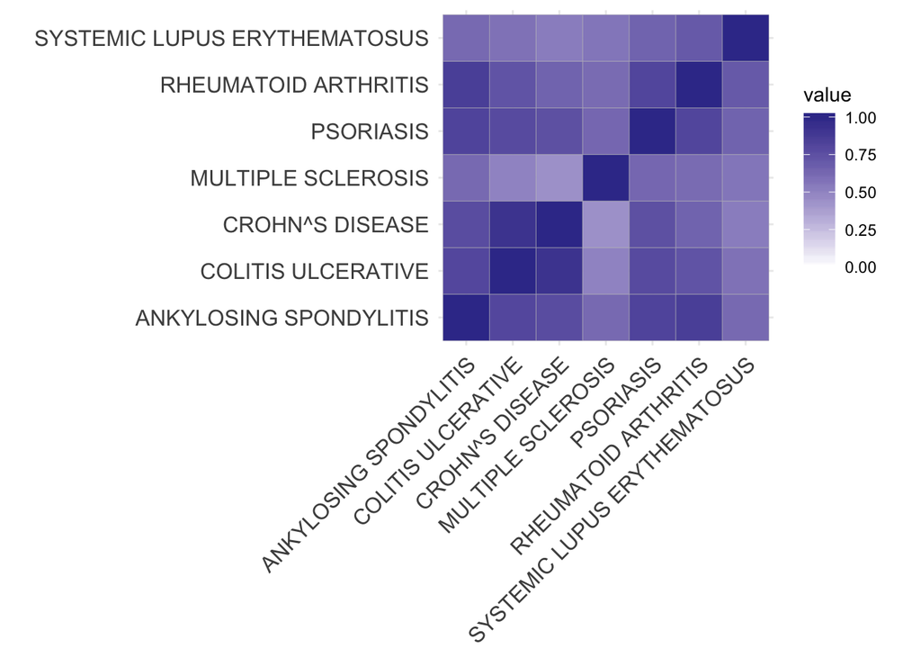

```r
cor.mat.plot
```

The low correlations with multiple sclerosis demonstrate that adverse events associated with the disease may be different than those with the other diseases. This may similarly be the case for lupus. There is evidence that many of the same adverse events are associated with rheumatoid arthritis, psoriasis, and ankylosing spondylitis. These associations could be mediated through drug use, given that many of the same medications (e.g. TNF inhibitors) are indicated for all of these conditions.

### Comparing the PRRs

It is not possible to make any conclusions about causality from this data because the total number of cases with each drug indication and adverse event is unknown, in addition to important unmeasured confounding. However we could pursue a more targeted research hypothesis for one particular adverse event. The proportional reporting ratio (PRR) has been used to measure if an adverse event in more common for a particular drug than for all drugs in a database. This can be translated to measure if an adverse event is more common for a disease. Below, I calculate the PRR of diarrhoea for the seven auto-immune conditions of interest.

PRR: (m/n)/((M-m)/(N-n))

Where: m is the reports with both disease and event n is reports with the disease M is reports with event in the data N is reports total in the data

```r
dt.M<-fromJSON("https://api.fda.gov/drug/event.json?search=_exists_:patient.drug.drugindication+AND+_exists_:patient.reaction.reactionmeddrapt+AND+receivedate:[20120101+TO+20191231]+AND+patient.patientonsetage:[18+TO+110]+AND+patient.reaction.reactionmeddrapt:diarrhoea&limit=1")
  M<-dt.M$meta$results$total

  dt.N<-fromJSON("https://api.fda.gov/drug/event.json?search=(receivedate:[20040101+TO+20191231])+AND+patient.patientonsetage:[18+TO+105]&limit=1")
  N<-dt.N$meta$results$total

    indication_query<-c("\"rheumatoid+arthritis\"", "\"psoriasis\"", "\"colitis+ulcerative\"", "\"crohn\"", "\"systemic+lupus+erythematosus\"", "\"multiple+sclerosis\"",  "\"ankylosing+spondylitis\"")
    m<-c()
    n<-c()
  for (i in seq(1:length(indication_query))){
    dt.m<-fromJSON(sprintf("https://api.fda.gov/drug/event.json?search=(receivedate:[20040101+TO+20191231])+AND+patient.patientonsetage:[18+TO+105]+AND+patient.reaction.reactionmeddrapt:diarrhoea+AND+patient.drug.drugindication:%s&limit=1", indication_query[i]))
  m[i]<-dt.m$meta$results$total

  dt.n<-fromJSON(sprintf("https://api.fda.gov/drug/event.json?search=(receivedate:[20040101+TO+20191231])+AND+patient.patientonsetage:[18+TO+105]+AND+patient.drug.drugindication:%s&limit=1", indication_query[i]))
  n[i]<-dt.n$meta$results$total
  }
```

```r
  M<-as.numeric(as.character(M))
  N<-as.numeric(as.character(N))

  df.prr<-as.data.frame(cbind(diseases, m, n))

  df.prr$m<-as.numeric(as.character(df.prr$m))
  df.prr$n<-as.numeric(as.character(df.prr$n))

  df.prr$prr<-(df.prr$m/df.prr$n)/((M-df.prr$m)/(N-df.prr$n))
  as_tibble(df.prr)
```

```
## # A tibble: 7 x 4
##   diseases                         m      n   prr
##   <fct>                        <dbl>  <dbl> <dbl>
## 1 RHEUMATOID ARTHRITIS         10174 381651 0.972
## 2 PSORIASIS                     7838 140143 2.10
## 3 COLITIS ULCERATIVE            2562  33773 2.80
## 4 CROHN^S DISEASE               5950  81248 2.74
## 5 SYSTEMIC LUPUS ERYTHEMATOSUS   519  11624 1.63
## 6 MULTIPLE SCLEROSIS           11575 316453 1.36
## 7 ANKYLOSING SPONDYLITIS        1009  38003 0.970
```

From these results, it appears that diarrhoea is not more common among reports that mention rheumatoid arthritis or ankylosing spondylitis than it is among all reports. This is in contrast to psoriasis, ulcerative colitis, and crohn’s disease, for which reports record diarrhoea more than twice as often. To a lesser extent, diarrhoea is also more commonly reported for systemic lupus erythematosus and multiple sclerosis.